# Introduction

07/17/2015

## Migrant route to Germany

[figure not shown]

[Overview of maps](http://www.lib.utexas.edu/maps/)

## The road to Europe

[figure not shown]

## GDP per capita

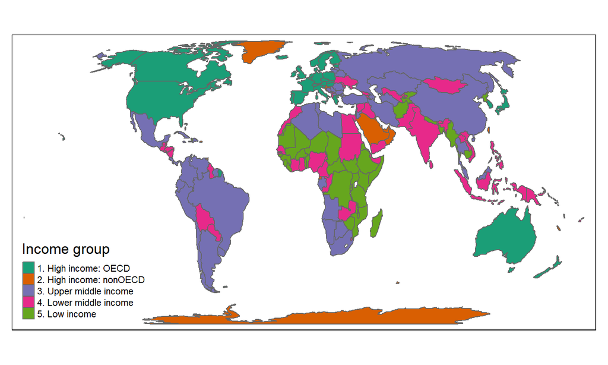

## Social index

Proportion of social benefits recipients in Berlin

[figure not shown]

## The spatial perspective…

- … is relevant to understand circumstances.
- More spatial visualisations are possible with data from web 2.0 etc.

## Target / Motivation

**The target is to visualize social aspects in maps.**

[figure not shown]

More [examples](http://spatial.ly/blog/)

## A little quiz

[figure not shown]

## A little quiz

- maps of photographic/traffic activity around the world
- data from [flickr](https://www.flickr.com/) used
- guess about picture taker's mode of transportation
- time stamps and distance traveled between a user's pictures

Black is walking (less than 7mph),

Red is bicycling or equivalent speed (less than 19mph),

Blue is motor vehicles on normal roads (less than 43mph);

Green is freeways or rapid transit.

## World Map Of Touristyness

[figure not shown]

## Tracking Taxis Across Manhattan

[figure not shown]

## Spatial? - Motivation

- Massive amounts of data … and growing!
- Often freely accessible on the web (e.g. through APIs)
- Often unstructured or semi-structured (e.g. web documents, news archives), often heterogeneous
- Often not intended for geographic purposes, but implicitly containing geographic info implicitly (Web 2.0)
- Often with little or no metadata

[Examples](https://www.flickr.com/groups/qgis/pool)

## Targets

I want to….

- … show you examples of useful and less useful visualisations and applications.
- … talk about the developments of maps/geography.
- … clarify, why it is important for social sciences.
- … show you how to produce your own maps/visualisations.
- … tell you where you can find data.

## Targets

Every participant should present his/her own maps.

- Presentation of toolbox (R, Google API, OpenStreetMap etc.)
- Learning by doing is very important

## Personal information

[interactive chart not shown]

## University of Trier

[figure not shown]

## Univerity Lyon III

[figure not shown]

## Organisation Gesis

Five departments - Survey Design and Methodology

- Monitoring Society and Social Change
- Data Archive for the Social Sciences
- Computational Social Science
- Knowledge Technologies for the Social Sciences

## Gesis

GESIS offers:

- Consulting for research projects in all phases
- Research based services

## Tasks GESIS-Team Statistics:

Consulting and research on …

- Planning of survey designs
- Development of sample designs for face-to-face, written, and telephone-assisted surveys
- Data analysis and visualisation

## Your background?

- Where do you come from?
- What are you studying?
- What are your main research interests?

## Tools and services

## Why use R

- It's free
- It's open source
- …

> R is the leading tool for statistics, data analysis, and machine learning. It is more than a statistical package; it’s a programming language, so you can create your own objects, functions, and packages.

Source: http://www.r-bloggers.com/why-use-r/

## Why use R

A big number of (very specific) packages:

[figure not shown]

[Overview of available packages on CRAN](http://www.r-pkg.org/)

## Why use R

[figure not shown]

## Why use R

- Interfaces with other programs, for example [Javascript](http://www.w3schools.com/js/), [ArcGis](http://uwm.edu/software/arcgis/), [GDAL](http://www.gdal.org/) and others…

[figure not shown]

## Why use R

R can be used as geographic information systems (GIS)

- R and [qgis](http://upload.wikimedia.org/wikipedia/commons/thumb/7/71/QGis_Logo.png/300px-QGis_Logo.png)
- Virgilio Gómez-Rubio - [Applied Spatial Data Analysis with R](http://www.uclm.es/profesorado/vgomez/useR2015/)
- [spatstat: Spatial Point Pattern Analysis](http://cran.r-project.org/web/packages/spatstat/index.html)
- [Task view mapping](https://github.com/ropensci/maptools)
- [giswerk](http://giswerk.org/)

## Why use R

Because it is possible to create nice graphics:

- [Producing Simple Graphs with R](http://www.harding.edu/fmccown/r/)
- [Lattice](http://stat.ethz.ch/R-manual/R-devel/library/lattice/html/Lattice.html)
- [R Graphics by Paul Murrell](https://www.stat.auckland.ac.nz/~paul/RGraphics/rgraphics.html)
- [Possibilities to visualize](http://mesa.ac.nz/wp-content/uploads/2012/05/all_presentations.pdf)
- [ggplot2 Tutorial](http://www.ceb-institute.org/bbs/wp-content/uploads/2011/09/handout_ggplot2.pdf)
- [Visualizing data in R](https://dl.dropboxusercontent.com/u/24648660/ggmap%201.pdf)
- [Interview Hadley Wickham - R-Project Data Visualization Guru](http://decisionstats.com/2010/01/12/interview-hadley-wickham-r-project-data-visualization-guru/)

## [Github](https://github.com/) stack

[figure not shown]

## Github page

- All relevant resources for this course will be available at:

https://github.com/Japhilko/GeoData

If you are interested in what is behind the scenes:

- [Introduction to Github](http://readwrite.com/2013/09/30/understanding-github-a-journey-for-beginners-part-1)

## How to learn R

- [Manuals on the R-project webpage](http://cran.r-project.org/manuals.html)
- Thomas Girke - [Programming in R](http://manuals.bioinformatics.ucr.edu/home/programming-in-r)
- Use [Reference cards](http://cran.r-project.org/doc/contrib/Baggott-refcard-v2.pdf), plot them and have them next to your computer
- [How to get help in R](http://itfeature.com/tag/how-to-get-help-in-r)

I will try to keep it simple and provide lots of resources.

## Basic R

[figure not shown]

## Download and install R

- Click [here](http://mirrors.softliste.de/cran/bin/windows/base/R-3.2.2-win.exe) to download R for Windows.
- R for other platforms (Linux and Mac OS) is available under:

http://mirrors.softliste.de/cran/

## Rstudio

[figure not shown]